# A1 - Preprocés de dades

Xavier Maltas

Març 2022

# 1 Càrrega de l’arxiu

```r
df.full <- read.csv("CensusIncomedataset.csv", sep=";")
```

Un cop disposem del Dataset complet carregat, realitzarem un breu estudi de les dades d’entrada a través de les següent instruccions.

```r
print(paste("Dataset contains", nrow(df.full), "registers"))
```

```
## [1] "Dataset contains 32560 registers"
```

La primera instrucció ens permet observar que disposem d’un total de 32560 registres.

```r
str(df.full)
```

```
## 'data.frame':    32560 obs. of  14 variables:
##  $ CS_ID         : chr  "CS1" "CS2" "CS3" "CS4" ...
##  $ age           : int  50 38 53 28 37 49 52 31 42 37 ...
##  $ workclass     : chr  " Self-Employed" " Private" " Private" " Private" ...
##  $ fnlwgt        : int  77516 83311 215646 234721 338409 284582 160187 209642 45781 159449 ...
##  $ education_num : int  13 9 7 13 14 5 9 14 13 10 ...
##  $ marital_status: chr  " Married" " Divorced" " Married" " Married" ...
##  $ relationship  : chr  "Not-in-family" "Husband" "Not-in-family" "Husband" ...
##  $ occupation    : chr  " White-Collar" " Blue-Collar" " Blue-Collar" " Professional" ...
##  $ race          : chr  " White" " White" " Black" " Black" ...
##  $ sex           : chr  " M" " M" " M" " Fem" ...
##  $ capital_gain  : int  2174 0 0 0 0 0 0 0 14084 5178 ...
##  $ capital_loss  : int  0 0 0 0 0 0 0 0 0 0 ...
##  $ hours_per_week: chr  "13,5 h" "40 h" "40,5 h" "40 h" ...
##  $ income        : chr  "2000,3 Milers d'euros" "51,67 Milers d'euros" "50,08 Milers d'euros" "44,21 Milers d'euros" ...
```

```r
summary(df.full)
```

```
##     CS_ID                age          workclass             fnlwgt
##  Length:32560       Min.   : 17.00   Length:32560       Min.   :  12285
##  Class :character   1st Qu.: 28.00   Class :character   1st Qu.: 117824
##  Mode  :character   Median : 37.00   Mode  :character   Median : 178356
##                     Mean   : 38.58                      Mean   : 189775
##                     3rd Qu.: 48.00                      3rd Qu.: 237046
##                     Max.   :650.00                      Max.   :1484705
##                     NA's   :7
##  education_num   marital_status     relationship        occupation
##  Min.   : 1.00   Length:32560       Length:32560       Length:32560
##  1st Qu.: 9.00   Class :character   Class :character   Class :character
##  Median :10.00   Mode  :character   Mode  :character   Mode  :character
##  Mean   :10.08
##  3rd Qu.:12.00
##  Max.   :16.00
##  NA's   :7
##      race               sex             capital_gain    capital_loss
##  Length:32560       Length:32560       Min.   :    0   Min.   :   0.00
##  Class :character   Class :character   1st Qu.:    0   1st Qu.:   0.00
##  Mode  :character   Mode  :character   Median :    0   Median :   0.00
##                                        Mean   : 1077   Mean   :  87.31
##                                        3rd Qu.:    0   3rd Qu.:   0.00
##                                        Max.   :99999   Max.   :4356.00
##
##  hours_per_week        income
##  Length:32560       Length:32560
##  Class :character   Class :character
##  Mode  :character   Mode  :character
##
##
##
##
```

```r
head(df.full)
```

```
##   CS_ID age      workclass fnlwgt education_num marital_status  relationship
## 1   CS1  50  Self-Employed  77516            13        Married Not-in-family
## 2   CS2  38        Private  83311             9       Divorced       Husband
## 3   CS3  53        Private 215646             7        Married Not-in-family
## 4   CS4  28        Private 234721            13        Married       Husband
## 5   CS5  37        Private 338409            14        Married          Wife
## 6   CS6  49        Private 284582             5        Married          Wife
##      occupation   race  sex capital_gain capital_loss hours_per_week
## 1  White-Collar  White    M         2174            0         13,5 h
## 2   Blue-Collar  White    M            0            0           40 h
## 3   Blue-Collar  Black    M            0            0         40,5 h
## 4  Professional  Black  Fem            0            0           40 h
## 5  White-Collar  White  Fem            0            0         40,5 h
## 6       Service  Black  Fem            0            0           16 h
##                  income
## 1 2000,3 Milers d'euros
## 2  51,67 Milers d'euros
## 3  50,08 Milers d'euros
## 4  44,21 Milers d'euros
## 5    0,1 Milers d'euros
## 6  43,93 Milers d'euros
```

# 2 Obtenció del dataset per fer l’estudi

```r
df <- df.full[!(names(df.full) %in% c("fnlwgt", "capital_gain", "capital_loss"))]
```

Un cop ja hem retirat els atributs innecessaris per l’anàlisi, a continuació extraurem aquells registres amb una alta quantitat de valors indefinits.

```r
colSums(is.na(df))
```

```
##          CS_ID            age      workclass  education_num marital_status
##              0              7              7              7              0
##   relationship     occupation           race            sex hours_per_week
##              7              7              7              0              0
##         income
##              0
```

```r
row.has.na <- apply(df, 1, function(x){any(is.na(x))})
df.with.na <- df[row.has.na,]
df.with.na
```

```
##         CS_ID age workclass education_num marital_status relationship
## 625     CS625  NA      <NA>            NA         Single         <NA>
## 7164   CS7164  NA      <NA>            NA         Single         <NA>
## 7454   CS7454  NA      <NA>            NA        Married         <NA>
## 8018   CS8018  NA      <NA>            NA        Married         <NA>
## 8088   CS8088  NA      <NA>            NA        Married         <NA>
## 9198   CS9198  NA      <NA>            NA        Married         <NA>
## 23655 CS23655  NA      <NA>            NA       Divorced         <NA>
##       occupation race     sex hours_per_week            income
## 625         <NA> <NA>       m         60,5 h          NA euros
## 7164        <NA> <NA>  Female         35,5 h NA Milers d'euros
## 7454        <NA> <NA>    Male           40 h NA Milers d'euros
## 8018        <NA> <NA>  Female         20,5 h NA Milers d'euros
## 8088        <NA> <NA>  Female           40 h NA Milers d'euros
## 9198        <NA> <NA>    Male         40,5 h NA Milers d'euros
## 23655       <NA> <NA>  Female         40,5 h NA Milers d'euros
```

Observem que són 7 el nombre de registres que contenen valors indefinits. A la vegada, tots ells es concentren als mateixos atributs. Així doncs, aquests hauran de ser extrets de la mostra tal com indiquen els paràmetres.

```r
#Generem una funció per comptabilitzar la quantitat de nuls de cada registre. Si és major de 5, l'eliminem
library('dplyr')
df$naCount <- apply(df, 1, function(x){sum(is.na(x))})
df <- df %>% filter(naCount < 5)
#Eliminem l'atribut creat per realitzar el cribratge
df <- df[!names(df) %in% c("naCount")]
```

Després d’eliminar els registres que contenen una gran quantitat de valors nuls, ens disposem a realitzar un *mapping* per intervals dels anys d’educació de cada persona.

```r
#Instal·lem la següent llibreria en cada de no disposar d'ella
### https://cran.r-project.org/web/packages/mappings/mappings.pdf
if(!require('mappings'))
  install.packages('remotes')
  library('remotes')
remotes::install_github("benjaminrich/mappings")
library(mappings)

#Creem els intervals i la funció de mappeig
education_cat_intervals <- c(0, 7, 10, 14, Inf)
m <- cut_mapping(education_cat_intervals, right=FALSE,
                 to=c("primaria", "secundaria", "universitaria", "postuniversitaria"))
print(m)
```

```
## Mapping
##  mapsfrom            mapsto
##     [0,7)          primaria
##    [7,10)        secundaria
##   [10,14)     universitaria
##  [14,Inf) postuniversitaria
```

```r
#Generem un nou atribut aplicant el mapping
df$education_cat<- m(df$education_num)
```

Finalment, realitzarem un canvi de nom de la variable *sex* per *gender*.

```r
df$gender <- df$sex
df <- df[!names(df) %in% c("sex")]
```

# 3 Duplicació de codis

En aquest tercer apartar, realitzarem la verificació i la modificació dels codis *CS_ID* en cas de que aquest es trobin duplicats.

```r
#Obtenim els registres que disposen d'un codi CS_ID duplicat
duplicates <- df[duplicated(df$CS_ID),]
duplicates
```

```
##         CS_ID age      workclass education_num marital_status   relationship
## 624     CS624  47        Private             5        Married        Husband
## 7162   CS7163  39        Private            15        Married  Not-in-family
## 7451   CS7453  31        Private            10       Divorced        Husband
## 8014   CS8017  33        Private            10      Separated Other-relative
## 8083   CS8087  30        Private            11       Divorced      Unmarried
## 9192   CS9197  47  Other/Unknown            13        Married  Not-in-family
## 23648 CS23654  34  Self-Employed            13       Divorced        Husband
##           occupation   race hours_per_week               income
## 624      Blue-Collar  White         40,5 h 54,52 Milers d'euros
## 7162    Professional  White           60 h 44,66 Milers d'euros
## 7451           Sales  White           35 h 42,98 Milers d'euros
## 8014    White-Collar  White         40,5 h 39,73 Milers d'euros
## 8083    White-Collar  White         40,5 h 52,28 Milers d'euros
## 9192   Other/Unknown  White         36,5 h 53,03 Milers d'euros
## 23648    Blue-Collar  White         60,5 h 50,69 Milers d'euros
##           education_cat  gender
## 624            primaria       m
## 7162  postuniversitaria  Female
## 7451      universitaria  Female
## 8014      universitaria  Female
## 8083      universitaria    Male
## 9192      universitaria    Male
## 23648     universitaria    Male
```

```r
#Ens quedem per separat amb els registres que no contenen codis CS_ID duplicats
without.duplicated.cs <- df %>% distinct(CS_ID, .keep_all = TRUE)

#Respecte a els registres amb codis duplicats, realitzem una modificació d'aquest
# a través d'afegir un zero entre els caràcters CS i el valor numèric, generant
# un nou codi únic
library(stringr)
addZeroCSID <- function(row){
  print(row)
  num <- as.numeric(str_extract(row, "[0-9]+"))
  paste("CS0",num, sep="")
}
duplicates$CS_ID <- addZeroCSID(duplicates$CS_ID)
```

```
## [1] "CS624"   "CS7163"  "CS7453"  "CS8017"  "CS8087"  "CS9197"  "CS23654"
```

```r
#Afegim de nou els registres, ara amb un nou codi CS_ID
#Unim el DataFrame sense duplicats amb el dels duplicats modificats
df <- rbind(without.duplicated.cs, duplicates)
```

# 4 Normalització de les dades qualitatives

## 4.1 Eliminació d’espais en blanc

```r
str(df)
```

```
## 'data.frame':    32553 obs. of  12 variables:
##  $ CS_ID         : chr  "CS1" "CS2" "CS3" "CS4" ...
##  $ age           : int  50 38 53 28 37 49 52 31 42 37 ...
##  $ workclass     : chr  " Self-Employed" " Private" " Private" " Private" ...
##  $ education_num : int  13 9 7 13 14 5 9 14 13 10 ...
##  $ marital_status: chr  " Married" " Divorced" " Married" " Married" ...
##  $ relationship  : chr  "Not-in-family" "Husband" "Not-in-family" "Husband" ...
##  $ occupation    : chr  " White-Collar" " Blue-Collar" " Blue-Collar" " Professional" ...
##  $ race          : chr  " White" " White" " Black" " Black" ...
##  $ hours_per_week: chr  "13,5 h" "40 h" "40,5 h" "40 h" ...
##  $ income        : chr  "2000,3 Milers d'euros" "51,67 Milers d'euros" "50,08 Milers d'euros" "44,21 Milers d'euros" ...
##  $ education_cat : Factor w/ 4 levels "primaria","secundaria",..: 3 2 2 3 4 1 2 4 3 3 ...
##  $ gender        : chr  " M" " M" " M" " Fem" ...
```

Mitjançant l’anterior comanda, podem observar que existeixen espais en blanc davant de múltiples atributs de tipus *character*. A continuació, eliminarem aquests espais en blanc.

```r
#Eliminació d'espais en blanc als dos costats de l'atribut
df$workclass <- trimws(df$workclass, which = c("both"))
df$marital_status <- trimws(df$marital_status, which = c("both"))
df$relationship <- trimws(df$relationship, which = c("both"))
df$occupation <- trimws(df$occupation, which = c("both"))
df$race <- trimws(df$race, which = c("both"))
df$gender <- trimws(df$gender, which = c("both"))
str(df)
```

```
## 'data.frame':    32553 obs. of  12 variables:
##  $ CS_ID         : chr  "CS1" "CS2" "CS3" "CS4" ...
##  $ age           : int  50 38 53 28 37 49 52 31 42 37 ...
##  $ workclass     : chr  "Self-Employed" "Private" "Private" "Private" ...
##  $ education_num : int  13 9 7 13 14 5 9 14 13 10 ...
##  $ marital_status: chr  "Married" "Divorced" "Married" "Married" ...
##  $ relationship  : chr  "Not-in-family" "Husband" "Not-in-family" "Husband" ...
##  $ occupation    : chr  "White-Collar" "Blue-Collar" "Blue-Collar" "Professional" ...
##  $ race          : chr  "White" "White" "Black" "Black" ...
##  $ hours_per_week: chr  "13,5 h" "40 h" "40,5 h" "40 h" ...
##  $ income        : chr  "2000,3 Milers d'euros" "51,67 Milers d'euros" "50,08 Milers d'euros" "44,21 Milers d'euros" ...
##  $ education_cat : Factor w/ 4 levels "primaria","secundaria",..: 3 2 2 3 4 1 2 4 3 3 ...
##  $ gender        : chr  "M" "M" "M" "Fem" ...
```

Ara ja podem observar que els espais en blanc que anteriorment podíem veure, ja no hi són.

## 4.2 Marital-Status

L’atribut *marital_status*, ens indica l’estat civil de l’individu. Per reduir l’espai d’aquesta variable, realitzarem un *mapping* canviant els diferents valors a un únic caràcter representatiu de cada estat.

```r
#En primer lloc, comprovem que només disposem de valors correctes
unique(df[c("marital_status")])
```

```
##     marital_status
## 1          Married
## 2         Divorced
## 8           Single
## 21       Separated
## 147        Widowed
```

```r
#Seguidament, realitzem una revalorització d'aquest atribut tal com ens indica l'enunciat
library('plyr')
df$marital_status <- revalue (x = df$marital_status, c("Married" = "M", "Single" = "S", "Separated" = "X", "Divorced" = "D", "Widowed" = "W"))
unique(df[c("marital_status")])
```

```
##     marital_status
## 1                M
## 2                D
## 8                S
## 21               X
## 147              W
```

Finalment, un cop comprovat que la revalorització s’ha realitzat correctament, representem gràficament la distribució dels valors d’aquesta variable. Els estats civils majoritaris són *Married* i *Single*.

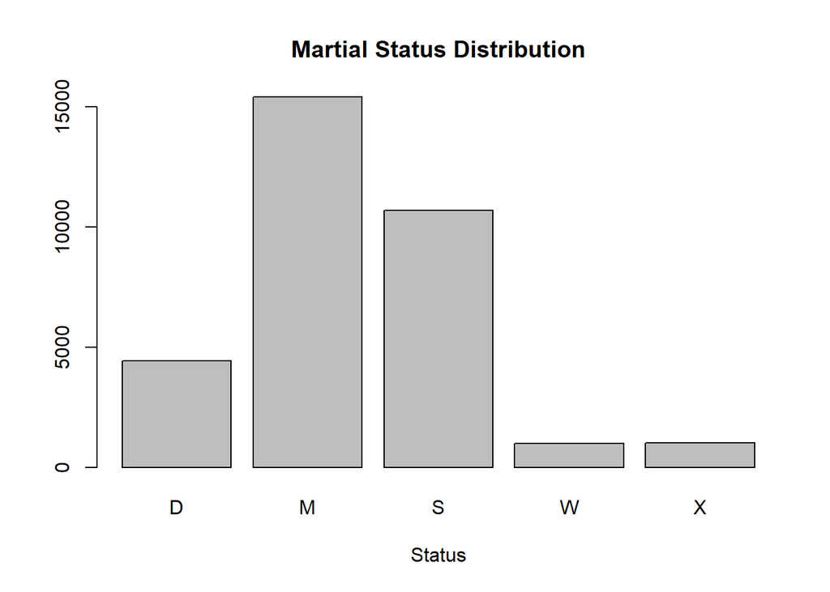

```r
if (!require('ggplot2')) install.packages('ggplot2'); library('ggplot2')
martial_status_table <- table(df$marital_status)
barplot(martial_status_table, main="Martial Status Distribution", xlab = "Status")
```

## 4.3 Gènere

En aquest apartat realitzarem una normalització de l’atribut *gender*. Observem al conjunt de dades, que hi ha múltiples formes d’expressar el mateix. És per aquest motiu, que duem a terme aquest procés d’estandardització.

```r
unique(df[c("gender")])
```

```
##      gender
## 1         M
## 4       Fem
## 603       m
## 1234      F
## 1334   male
## 2799 female
## 2961   Male
## 6146 Female
```

```r
df$gender <- revalue (x = df$gender, c("M" = "m", "Fem" = "f", "F" = "f", "male" = "m", "female" = "f", "Male" = "m", "Female" = "f"))
```

Finalment, un cop disposem de les dades estandarditzades, representem gràficament la distribució del paràmetre *gender*, on veiem que la mostra es compon per molts més homes que dones.

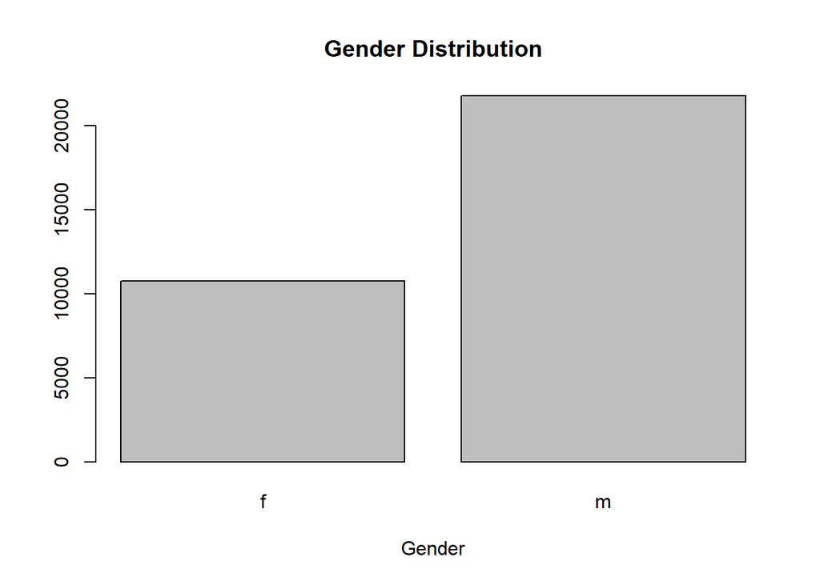

```r
gender_table <- table(df$gender)
barplot(gender_table, main="Gender Distribution", xlab = "Gender")
```

# 5 Normalització de les dades quantitatives

## 5.1 Edat

Analitzant els valors únics que pren el paràmetre *age* observem que hi ha dos registres que tenen un valor incoherent. És per aquest motiu, que deixarem aquests atributs com a valors nuls.

```r
#unique(df[c("age")]) #uncomment to see all values

#Replace a valors NA
if (!require('naniar')) install.packages('naniar'); library('naniar')
df <- df%>% replace_with_na(replace = list(age = c(650,560)))
#Visualitzem que ara si que tenim valors NA al camp 'age'
colSums(is.na(df))
```

```
##          CS_ID            age      workclass  education_num marital_status
##              0              2              0              0              0
##   relationship     occupation           race hours_per_week         income
##              0              0              0              0              0
##  education_cat         gender
##              0              0
```

```r
#Comprovem els dos registres
filter(df, CS_ID == 'CS430')
```

```
##     CS_ID age     workclass education_num marital_status relationship
## 430 CS430  NA Other/Unknown             9              W      Husband
##        occupation  race hours_per_week               income education_cat
## 430 Other/Unknown White         24,5 h 43,53 Milers d'euros    secundaria
##     gender
## 430      m
```

```r
filter(df, CS_ID == 'CS2754')
```

```
##       CS_ID age     workclass education_num marital_status relationship
## 2752 CS2754  NA Self-Employed             4              M      Husband
##       occupation  race hours_per_week               income education_cat gender
## 2752 Blue-Collar White         30,5 h 55,28 Milers d'euros      primaria      m
```

A continuació, mostrem com es distribueixen els valors de la variable *age*.

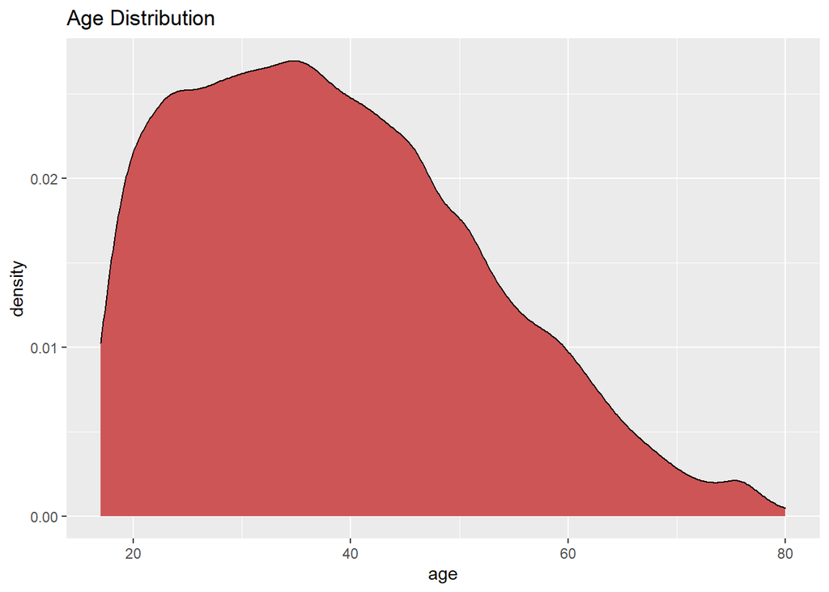

```r
ggplot(df, aes(x = age)) +
  geom_density(fill = "indianred3") +
  labs(title = "Age Distribution")
```

## 5.2 Educació

```r
#unique(df[c("education_num")]) #uncomment to see all values
```

Un cop analitzat els valors que pot tenir l’atribut *education_num*, podem determinar que no hi ha cap comportament incoherent. A continuació, mostrarem la distribució d’aquests valors, on podem veure que els registres es concentren entre els 9 i 13 anys.

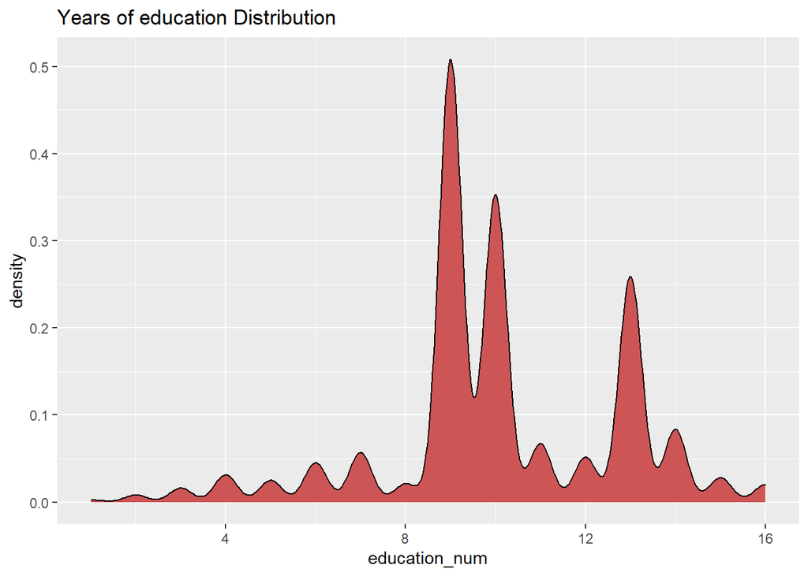

```r
ggplot(df, aes(x = education_num)) +
  geom_density(fill = "indianred3") +
  labs(title = "Years of education Distribution")
```

## 5.3 Hores per setmana

```r
#Obtenim la class de la variable _hours_per_week -> character
sapply(df,class)
```

```
##          CS_ID            age      workclass  education_num marital_status
##    "character"      "integer"    "character"      "integer"    "character"
##   relationship     occupation           race hours_per_week         income
##    "character"    "character"    "character"    "character"    "character"
##  education_cat         gender
##       "factor"    "character"
```

```r
# unique(df[c("hours_per_week")]) #uncomment to see all values
```

El paràmetre *hours_per_week* és de tipus *character*, tot i que realment ens interessa que sigui de tipus *numeric*. En primer lloc, hem d’eliminar les unitats i seguidament transformar aquest valor a tipus *numeric*.

```r
#Realitzem una funció que extreu el valor i fa el casting a tipus numeric
extractNum <- function(row){
  num <- gsub("[a-zA-Z ]", "", row) #Elimiem caracters
  num <- as.numeric(gsub(",", ".",num)) #Comma to dot, to numeric
}
df$hours_per_week <- extractNum(df$hours_per_week)
#Comprovació del canvi de tipus i eliminació de les unitats
sapply(df,class)
```

```
##          CS_ID            age      workclass  education_num marital_status
##    "character"      "integer"    "character"      "integer"    "character"
##   relationship     occupation           race hours_per_week         income
##    "character"    "character"    "character"      "numeric"    "character"
##  education_cat         gender
##       "factor"    "character"
```

## 5.4 Income

La variable *income* ha d’estar expressada en milers d’euros. Dins el nostre conjunt de dades, observem que hi ha dues maneres de representar-la. És per aquest motiu que hem de realitzar una primera estandardització d’unitats i seguidament en tipus de variable, ja que inicialment és de tipus *character*.

```r
#Funció per extreure el tipus d'unitat (euros, milers d'euros)
extractMoneyUnit <- function(row){
  unit <- gsub('[0-9]+', '', row)
  unit <- gsub(",", "", unit)
  unit <- trimws(unit, which = c("both"))
}

#Funció per extreure la quantitat a tipus numeric
extractMoneyAmount <- function(row){
  num <- gsub("[a-zA-Z ]", "", row)
  num <- gsub("'", "", num)
  num <- as.numeric(gsub(",", ".",num))

}

#Afegir dos parametres nous que ens seriviran per realitzar l'estandariatzació final
df$moneyUnit <- extractMoneyUnit(df$income)
df$amountIncome <- extractMoneyAmount(df$income)

#Funció per normalitzar tots els valors a milers d'euros tipus numèric
normalizeAmount <- function(unit, amount){
  num <- ifelse(unit == "euros", amount/1000, amount)
}

df$income <- normalizeAmount(df$moneyUnit, df$amountIncome)
#Eliminem les dues variables auxiliars
df <- df[!names(df) %in% c("moneyUnit", "amountIncome")]
```

# 6 Valors atípics

En aquest apartat ens dedicarem a analitzar les variables *age*, *education_num*, *hours_per_week* i *income*, per tal d’intentar observar si hi ha i quins són els valors atípics o outliers.

## 6.1 Age

Per començar observem diferents estadistiques corresponents a la distribució de la variable i grafiant el boxplot.

```r
#Estadistiques
summary(df$age)
```

```
##    Min. 1st Qu.  Median    Mean 3rd Qu.    Max.    NA's
##   17.00   28.00   37.00   38.55   48.00   80.00       2
```

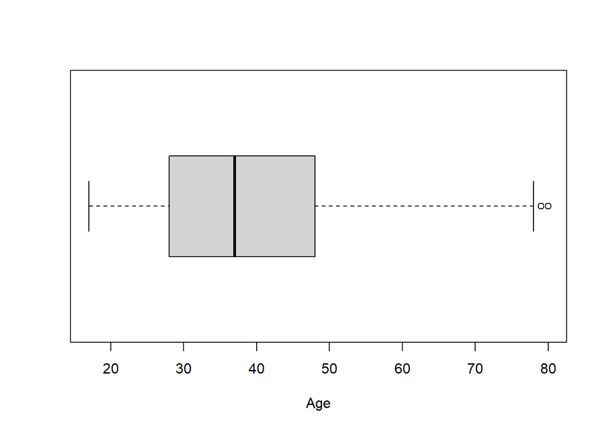

```r
#BoxPlot
age.bp <- boxplot(df$age, xlab = "Age", horizontal=TRUE)
```

A través de les estadístiques anteriors i el *BoxPlot* podem veure que les dades es concentren entre el rang dels 25-50 anys. Els valors superiors al 77 anys aproximadament són considerats outliers segons el gràfic BoxPlot.

```r
#Obtenir els considerats outliers
ageOutliersAge <- age.bp$out
#ageOutliersAge #uncomment to see all values
```

Nosaltres, per a calcular els intervals, farem servir el criteri +/-2SD, que ens permetrà establir els rangs sobre els quals treballar.

```r
###Criteri +/-2SD
age.mean<-mean(df$age, na.rm=TRUE) #Calcul Mean
age.sd<-sd(df$age, na.rm=TRUE) #Calcul Standard Deviation
age.cutoff<- age.sd*2
print(paste("Cutoff: ",age.cutoff))
```

```
## [1] "Cutoff:  27.0840051237677"
```

```r
age.upperBoundary <- age.mean+age.cutoff #upper boundary
age.lowerBoundary <- age.mean-age.cutoff #Lower boundary
print(paste("Range: [", age.lowerBoundary, ",",age.upperBoundary, "]"))
```

```
## [1] "Range: [ 11.4658397350692 , 65.6338499826046 ]"
```

```r
#Funció per posar els valors fora del rang com a NA
NAAge <- function(lower, upper, age){
  num <- ifelse ( (lower < age ) & ( age < upper ), age, NA)
}
df$age <- NAAge(age.lowerBoundary,age.upperBoundary,df$age)
```

## 6.2 Education_num

Per analitzar aquest paràmetre seguirem el mateix procediment que en l’anterior.

```r
#Estadistiques
summary(df$education_num)
```

```
##    Min. 1st Qu.  Median    Mean 3rd Qu.    Max.
##    1.00    9.00   10.00   10.08   12.00   16.00
```

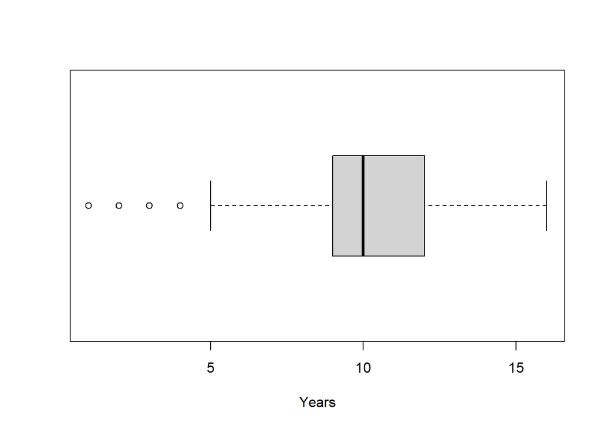

```r
#BoxPlot
education_num.bp <- boxplot(df$education_num, xlab = "Years", horizontal=TRUE)
```

Tal com hem esmentat anteriorment a l’apartat 5.2, els valors majoritaris corresponents a la quantitat d’anys estudiats dins la mostra es concentra entre 9 i 12. Per altra banda, observem un seguit de registres que es troben bastant fora de la majoria a la zona baixa del BoxPlot. Aquests rangs corresponen a 1-5 anys. Tot i que són valors summament estranys, considerem que no han de ser eliminats, ja que desconeixem els orígens socioeconòmics de l’individu, així com el país d’origen i la situació que hi havia durant la seva etapa infantil, que és la que majoritàriament es dedica a la formació.

```r
#Obtenir els considerats outliers
educationNumOutliersAge <- education_num.bp$out
#educationNumOutliersAge #uncomment to see all values
```

## 6.3 Hours per week

Mitjançant les estadistiques podem observar que les hores per setmana realitzades per a cada individu es trobem majoritariament concentrades entre 40 i 45 hores. A la vegada, a través del BoxPlot podem observar que hi ha molts registres que es troben per sota d’aquest rang, pero encara més que es troben per sobre.

```r
#Estadistiques
summary(df$hours_per_week)
```

```
##    Min. 1st Qu.  Median    Mean 3rd Qu.    Max.
##    1.00   40.00   40.50   40.71   45.50   99.50
```

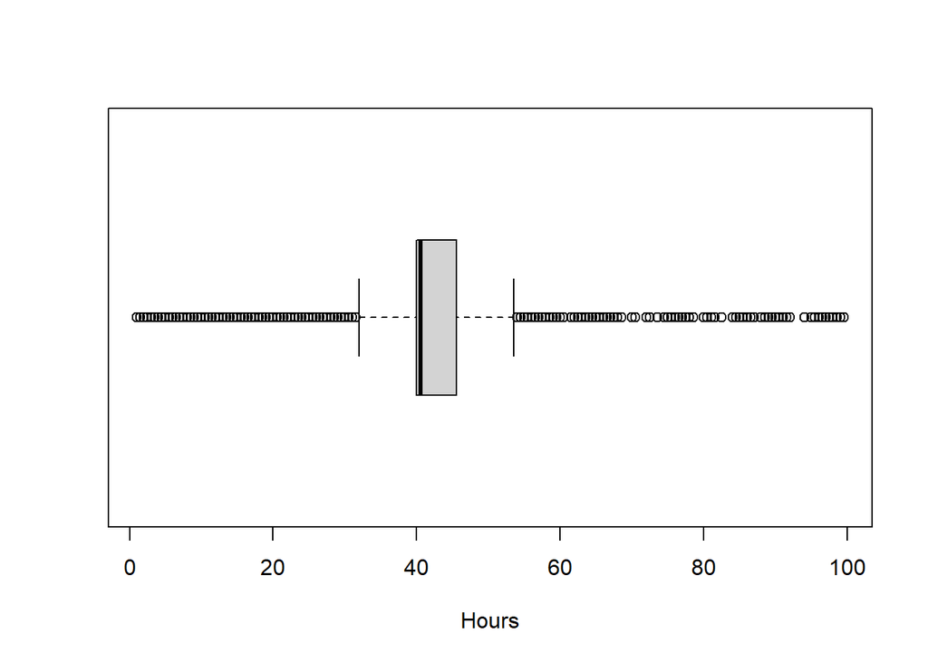

```r
#BoxPlot
hours_per_week.bp <- boxplot(df$hours_per_week, xlab = "Hours", horizontal=TRUE)
```

Seguint els valors establerts de l’enunciat, es consideraran outliers aquells valors que siguin superiors a 80 hores setmanals. Així que a continuació, deixarem com a NA els valors que superen aquesta xifra.

```r
#Funció per posar els valors superiors a 80 com a NA
NAhoursAbove80 <- function(hours){
  num <- ifelse(hours > 80, NA, hours)
}

df$hours_per_week <- NAhoursAbove80(df$hours_per_week)
```

## 6.4 Income

```r
#Estadistiques
summary(df$income)
```

```
##    Min. 1st Qu.  Median    Mean 3rd Qu.    Max.
##    0.10   43.22   49.71   48.88   54.32 2134.60
```

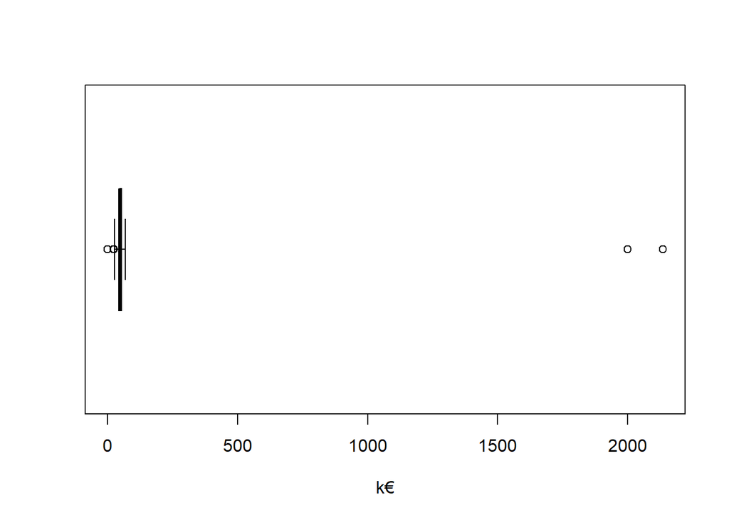

```r
#BoxPlot
income.bp <- boxplot(df$income, xlab = "k€", horizontal=TRUE)
```

Els outliers corresponen al següents valors:

```r
incomeOutliersAge <- income.bp$out
incomeOutliersAge
```

```
## [1] 2000.30    0.10 2134.60   22.54   25.71   25.06   26.04   25.69
```

Els valors que tenen una tendència més a la baixa, poden tenir algun tipus de relació, a persones que fan menys hores (estudiar i treballar). Mentre que els valors corresponents a xifres desorbitades, podríem estar parlant de persones que són multimilionàries. Com a tal, tot i ser valors molt llunyans als estàndard vistos, no poden ser tractats com a outliers, ja que descriuen situacions que són plausibles.

# 7 Imputació de valors

En aquest apartat ens dedicarem a atribut valor a les variables quantitaties que hem deixat com a valors NA.

## 7.1 Age

La variable *age* és una de les que anteriorment hem atribuit valors NA als outliers. Per tal de realitzar la imputació d’aquests valors, aplicarem la mitjana aritmètica.

```r
#Funció per aplicar la mitjana aritmètica als valors NA
NAtoMeanAge <- function(age, mean){
  num <- ifelse(is.na(age), mean, age)
}
age.mean<-mean(df$age, na.rm=TRUE) #Mean computation
df$age <- NAtoMeanAge(df$age, age.mean)
```

## 7.2 Income

A la variable *income* no s’ha modificat cap registre, ja que tal com hem explicat anteriorment, hem determinat que tot i haver valors molt allunyats dels estàndards, aquests poden descriure una situació real. Així doncs, en aquest apartat no s’ha de realitzar cap imputació.

## 7.3 Education_num

L’atribut *education_num*, al igual que la variable *income* no ha estat modificada a l’apartat anterior pel motius esmentat. Així doncs, en aquest apartat no s’ha de realitzar cap imputació.

## 7.4 Hours per week

```r
if(!require('VIM'))
  install.packages('VIM')
library('VIM')

#Funció per posar NA com mitjançant la funció kNN - Not working
NAToKNN <- function(hours){
  #knnimp <- kNN(hours, k = 11)
  #num <- ifelse(is.na(hours), knnimp, hours)
}

#df$hours_per_week <- NAToKNN(df$hours_per_week)
```

# 8 Estudi descriptiu

## 8.1 Funcions de mitjana robustes

### 8.1.1 Mitjana retallada

```r
#Definició de la funció
mitjana.retallada <- function(x, perc=0.05){
  v <- mean(x,trim=perc)
}

#Set
x=c(800,6,4,5,5,5,5,6,4,2)

#Execució
a <- mitjana.retallada(x)
```

### 8.1.2 Mitjana Winsor

```r
if(!require('psych'))
  install.packages('psych')
library('psych')

#Definició de la funció
mitjana.winsor <- function(x, perc=0.05){
  v <- winsor.mean(x, trim=perc)
}

#Set
x=c(800,6,4,5,5,5,5,6,4,2)

#Execució
b <- mitjana.winsor(x)
```

# 9 Arxiu final

Un cop realitzat el processament sobre l’arxiu, guardarem les dades dins d’un fitxer anomenant *‘CensusIncome_clean.csv’*.

```r
write.csv(df,"CensusIncome_clean.csv", row.names = TRUE)
```